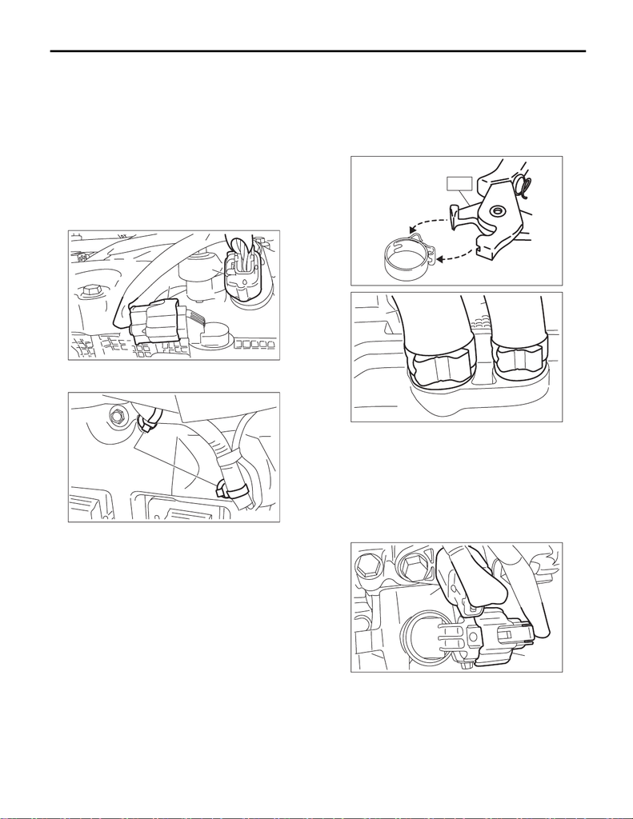

ME(STI)-26

Valve Clearance

MECHANICAL

8. Valve Clearance

A: INSPECTION

1) Disconnect the ground cable from battery.

2) Remove the engine from vehicle. <Ref. to

ME(STI)-30, REMOVAL, Engine Assembly.>

3) Remove the timing belt cover RH. <Ref. to

ME(STI)-50, REMOVAL, Timing Belt Cover.>

4) When inspecting #1 and #3 cylinders

(1) Disconnect the connector (A) from the ex-

haust camshaft position sensor RH and the

connector (B) form the exhaust oil flow control

solenoid valve RH.

(2) Remove the clip (A) which hold the engine

harness to the rocker cover RH.

(3) Remove the ignition coil. <Ref. to IG(STI)-7,

REMOVAL, Ignition Coil.>

(4) Disconnect PCV hose (A) and vacuum hose

(B) from the rocker cover RH.

NOTE:

Pinch the clamp by fitting the cut out in the ST with

the protrusion on the clamp as shown in the figure,

and unlock the clamp.

ST 18353AA000 CLAMP PLIERS

(5) Remove the rocker cover RH.

5) When inspecting #2 and #4 cylinders

(1) Remove the secondary air pump. <Ref. to

EC(STI)-53, REMOVAL, Secondary Air

Pump.>

(2) Disconnect the connector (A) from the ex-

haust camshaft position sensor LH and the con-

nector (B) form the exhaust oil flow control

solenoid valve LH.

ME-05009

(B)

(A)

ME-05041

(A)

ME-04374

ST

ME-07958

(A)

(B)

ME-05010

(B)

(A)

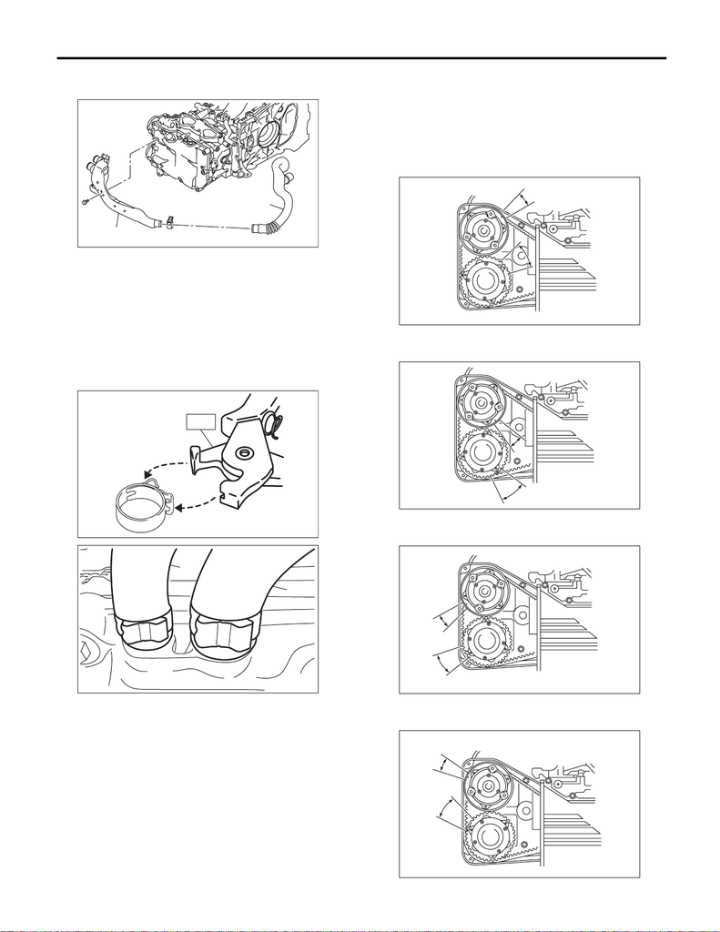

ME(STI)-27

Valve Clearance

MECHANICAL

(3) Remove the air duct B (B) from the rocker

cover LH and the air duct A (A).

(4) Remove the ignition coil. <Ref. to IG(STI)-7,

REMOVAL, Ignition Coil.>

(5) Disconnect PCV hose (A) and vacuum hose

(B) from the rocker cover LH.

NOTE:

Pinch the clamp by fitting the cut out in the ST with

the protrusion on the clamp as shown in the figure,

and unlock the clamp.

ST 18353AA000 CLAMP PLIERS

(6) Remove the rocker cover LH.

6) Turn the crank pulley clockwise until the round

mark on the camshaft sprocket is set to position

shown in the figure.

NOTE:

Turn the crank pulley using a socket wrench.

• Measurement of clearance of #1 cylinder intake

valve and #3 cylinder exhaust valve

• Measurement of clearance of #2 cylinder ex-

haust valve and #3 cylinder intake valve

• Measurement of clearance of #2 cylinder intake

valve and #4 cylinder exhaust valve

• Measurement of clearance of #1 cylinder ex-

haust valve and #4 cylinder intake valve

ME-04953

(B)

(A)

ME-04374

ST

ME-07959

(A)

(B)

ME-04090

ME-03121

ME-03122

ME-03123

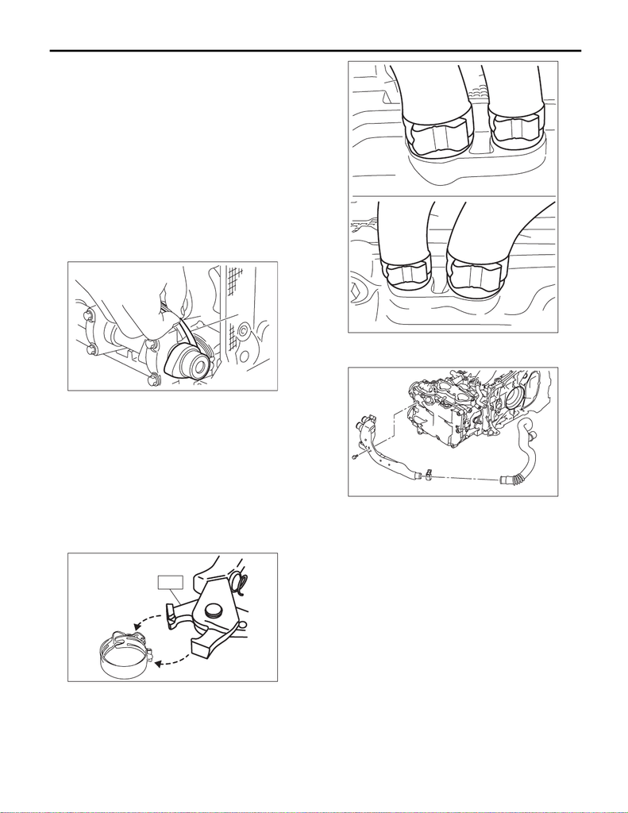

ME(STI)-28

Valve Clearance

MECHANICAL

7) Measure the clearance of intake valve and ex-

haust valve using thickness gauge (A).

NOTE:

• Insert a thickness gauge in a direction as hori-

zontal as possible with respect to the valve lifter.

• Lift up the vehicle, and then measure the ex-

haust valve clearances.

• If the measured value is not within the inspection

value, take notes of the value in order to adjust the

valve clearance later on.

Valve clearance (inspection value):

Intake

0.20

+0.04

–0.06

mm (0.0079

+0.0016

–0.0024

in)

Exhaust

0.35

±

0.05 mm (0.0138

±

0.0020 in)

8) If necessary, adjust the valve clearance. <Ref. to

ME(STI)-29, ADJUSTMENT, Valve Clearance.>

9) After inspection, install the related parts in the

reverse order of removal.

NOTE:

• Refer to “Camshaft” when installing the rocker

cover. <Ref. to ME(STI)-64, INSTALLATION, Cam-

shaft.>

• Use a new clamp, fit the cut out in the ST with the

protrusion on the clamp as shown in the figure, and

lock the clamp.

ST 18353AA000 CLAMP PLIERS

Tightening torque:

6.4 N·m (0.7 kgf-m, 4.7 ft-lb)

ME-04958

(A)

ME-08033

ST

ME-07960

(A)

(A)

(B)

(B)

ME-04954

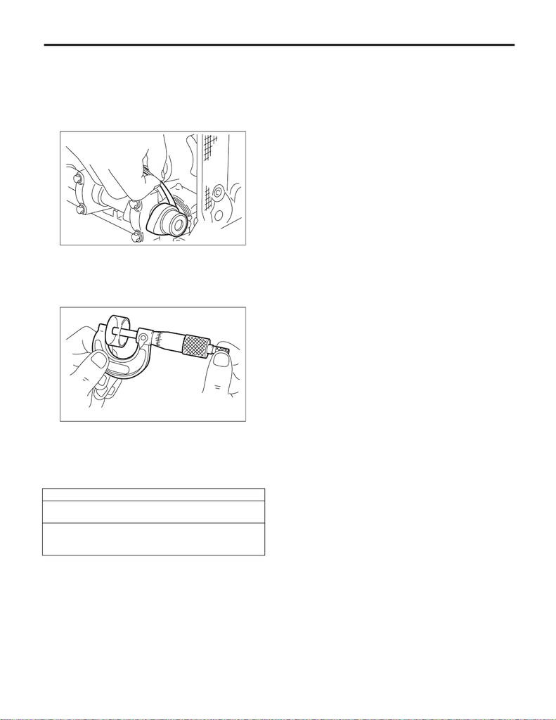

ME(STI)-29

Valve Clearance

MECHANICAL

B: ADJUSTMENT

1) Measure all the valve clearances. <Ref. to

ME(STI)-26, INSPECTION, Valve Clearance.>

NOTE:

Record the measured value of each valve clear-

ance.

2) Remove the camshaft. <Ref. to ME(STI)-62, RE-

MOVAL, Camshaft.>

3) Remove the valve lifter.

4) Measure the thickness of valve lifter using mi-

crometer.

5) Select a valve lifter of suitable thickness using

the measured valve clearance and valve lifter thick-

ness, and install it.

NOTE:

Use a new valve lifter.

6) Install the camshaft. <Ref. to ME(STI)-64, IN-

STALLATION, Camshaft.>

7) Install the cam sprocket. <Ref. to ME(STI)-60,

INSTALLATION, Cam Sprocket.>

8) Install the timing belt. <Ref. to ME(STI)-54, TIM-

ING BELT, INSTALLATION, Timing Belt.>

9) Measure all valves for valve clearance again at

this time. If the valve clearance is not within the ad-

justment value, repeat the procedure over again

from step 2).

Valve clearance (adjustment value):

Intake

0.20

+0.01

–0.03

mm (0.0079

+0.0004

–0.0012

in)

Exhaust

0.35

±

0.02 mm (0.0138

±

0.0008 in)

10) After adjustment, install the related parts in the

reverse order of removal.

Unit: mm (in)

Intake valve: S = (V + T) – 0.19 (0.0075)

Exhaust valve: S = (V + T) – 0.35 (0.0138)

S: Valve lifter thickness required

V: Measured valve clearance

T: Valve lifter thickness to be used

ME-00024

ME-00025